# final_R_reference

Ragib Ahsan

12/16/2021

# R Reference Guide

## Loading Data and Packages

- Use these to show how to load the here and palmerpenguins packages - libary() and require()
- Ginkgo data: use the 2021 ginkgo data to create a data.frame called ginkgo using:

### Require() function

This function used for loading the packages, which is already ready to use in R.

```r
require(here)
```

### Library() function

This function is about the all stored and downloaded packages in R

```r
library(palmerpenguins)
```

### Read.csv() function

this function allows csv files to open and rean in R.

```r
ginkgo = data.frame(read.csv(here("data", "ginkgo_data_2021.csv")))
```

## Data Structures

### c() function

The function c() combines or concatenates its arguments into a vector (a 1-dimensional data structure consisting of 1 or more elements).

- All of the elements must be of the same type.
  - I can’t combine character and numeric types in the same call to c()

Here’s two examples using numeric and character data types:

```r
## Create a vector of numbers:
num_vec  = c(1, 4, 8, 9, 13)

## Create a vector of characters:
char_vec = c("a", "fish", "data is cool")
```

I can show the contents of a vector by typing the name of the vector, or using the print() function.

```r
## Typing the name of the vector into the console prints the contents
num_vec
```

```
## [1]  1  4  8  9 13
```

```r
## The print() function accomplishes the same task:
print(char_vec)
```

```
## [1] "a"            "fish"         "data is cool"
```

### print() function

This function print the contents of the vectors

```r
print(char_vec)
```

```
## [1] "a"            "fish"         "data is cool"
```

### length() function

This functions deals with the length of the vectors

```r
length(num_vec)
```

```
## [1] 5
```

```r
length(char_vec)
```

```
## [1] 3
```

### matrix() function

This function create a matrix from a given set of values to a no of rows and column.

```r
matrix(num_vec, nrow = 3, ncol = 5, byrow = TRUE)
```

```
##      [,1] [,2] [,3] [,4] [,5]
## [1,]    1    4    8    9   13
## [2,]    1    4    8    9   13
## [3,]    1    4    8    9   13
```

### data.frame() function

DataFrame is a data structure, organizes data into a table with rows and column. * We can say ginkgo is a data frame and we can vizualize the ginkgo data as a table in R

```r
ginkgo
```

```
##     site_id seeds_present max_width max_depth notch_depth petiole_length
## 1      7719         FALSE      71.0        40         0.0          30.00
## 2      7719         FALSE      64.0        38         0.0          23.00
## 3      7719         FALSE      55.0        32         0.0          20.00
## 4      7719         FALSE      62.0        40         0.0          28.00
## 5      7719         FALSE      65.0        40         0.0          25.00
## 6      7719         FALSE      70.0        50         0.0          55.00
## 7      7719         FALSE      63.0        42         0.0          27.00
## 8      7719         FALSE      56.0        35         0.0          20.00
## 9      7719         FALSE      51.0        45         0.0          50.00
## 10     7719         FALSE      57.0        37         0.0          23.00
## 11     7719         FALSE      59.0        41         0.0          28.00
## 12     7719         FALSE      63.0        42         0.0          26.00
## 13     7719         FALSE      70.0        50         0.0          43.00
## 14     7719         FALSE      50.0        46         0.0          45.00
```

[output cut: 742 more lines]

### Several useful functions to vizualize the specific data information from the DataFrame:

### nrow() function

```r
## Helps to vidualize the rows prsent in a data frame
nrow(ginkgo)
```

```
## [1] 756
```

### ncol() function

```r
## Helps to vidualize the columns prsent in a data frame
ncol(ginkgo)
```

```
## [1] 6
```

### dim() function

```r
## Helps to vidualize the rows and columns prsent in a data frame
dim(ginkgo)
```

```
## [1] 756   6
```

## Subsetting

Useful function in R, which allow to filter only the specific part from the data set or data

### $

Selecting or mentioning (subsetting) a data set by the name

```r
head(ginkgo$petiole_length)
```

```
## [1] 30 23 20 28 25 55
```

### []

Selects data sets py position

```r
## Select the first row.
head(ginkgo[1,])
```

```
##   site_id seeds_present max_width max_depth notch_depth petiole_length
## 1    7719         FALSE        71        40           0             30
```

```r
## Select the third column.
head(ginkgo[,3])
```

```
## [1] 71 64 55 62 65 70
```

### subset() function

subset use to select a certain subset from vectors, matrices or data frames

```r
## Recover all Adelie penguins data from the "palmerpenguins" dataset.
head(subset(penguins, species == "Adelie"))
```

```
## # A tibble: 6 x 8
##   species island bill_length_mm bill_depth_mm flipper_length_… body_mass_g sex
##   <fct>   <fct>           <dbl>         <dbl>            <int>       <int> <fct>
## 1 Adelie  Torge…           39.1          18.7              181        3750 male
## 2 Adelie  Torge…           39.5          17.4              186        3800 fema…
## 3 Adelie  Torge…           40.3          18                195        3250 fema…
## 4 Adelie  Torge…           NA            NA                 NA          NA <NA>
## 5 Adelie  Torge…           36.7          19.3              193        3450 fema…
## 6 Adelie  Torge…           39.3          20.6              190        3650 male
## # … with 1 more variable: year <int>
```

## Numerical Data Exploration

### summary() function

This function provides the model summary

```r
summary(penguins)
```

```
##       species          island    bill_length_mm  bill_depth_mm
##  Adelie   :152   Biscoe   :168   Min.   :32.10   Min.   :13.10
##  Chinstrap: 68   Dream    :124   1st Qu.:39.23   1st Qu.:15.60
##  Gentoo   :124   Torgersen: 52   Median :44.45   Median :17.30
##                                  Mean   :43.92   Mean   :17.15
##                                  3rd Qu.:48.50   3rd Qu.:18.70
##                                  Max.   :59.60   Max.   :21.50
##                                  NA's   :2       NA's   :2
##  flipper_length_mm  body_mass_g       sex           year
##  Min.   :172.0     Min.   :2700   female:165   Min.   :2007
##  1st Qu.:190.0     1st Qu.:3550   male  :168   1st Qu.:2007
##  Median :197.0     Median :4050   NA's  : 11   Median :2008
##  Mean   :200.9     Mean   :4202                Mean   :2008
##  3rd Qu.:213.0     3rd Qu.:4750                3rd Qu.:2009
##  Max.   :231.0     Max.   :6300                Max.   :2009
##  NA's   :2         NA's   :2
```

### mean () function

This function provides the average (mean) of a data set

```r
# For observing the mean bill length
mean(penguins$bill_length_mm, na.rm = TRUE)
```

```
## [1] 43.92193
```

### sd() function

This function produces the standard daviation from a dataset. For example we can calculate the standard deviation of bill length

```r
sd(penguins$bill_length_mm, na.rm = TRUE)
```

```
## [1] 5.459584
```

## Graphical Data Exploration

### Scatterplot()

- Scatterplot can be generated usung the plott() function. Plot requires arguments as following:

col: Deals with the colors. Useful functions for using the colors are- rgb() and colors() functions (color names and IDs)

pch: Assigns the types of points (circle, triangle, star etc.) within the plot

cex: Specifies the size of the points in the scatterplot

main: Title of the plot

xlab: Title of x-axis

ylab: Title of y-axis

xlim: Controls the minimum and maximum values in the x-axis

ylim: Controls the minimum and maximum values in the y-axis

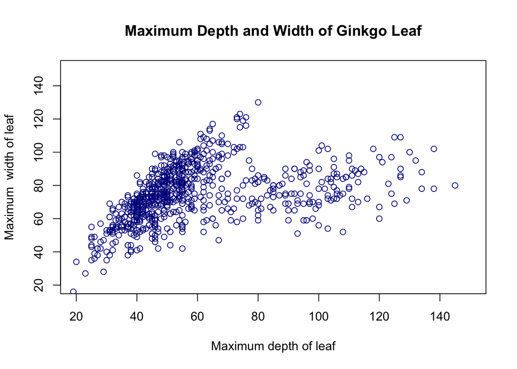

```r
plot(max_width ~ max_depth, data = ginkgo, main = "Maximum Depth and Width of Ginkgo Leaf",
     xlab = "Maximum depth of leaf", ylab = "Maximum  width of leaf",
     pch = 1, cex = 1,
     col = "blue4",
     xlim = c(20,150),
     ylim = c(20,150)
)
```

### hist() function

Creates histogram.

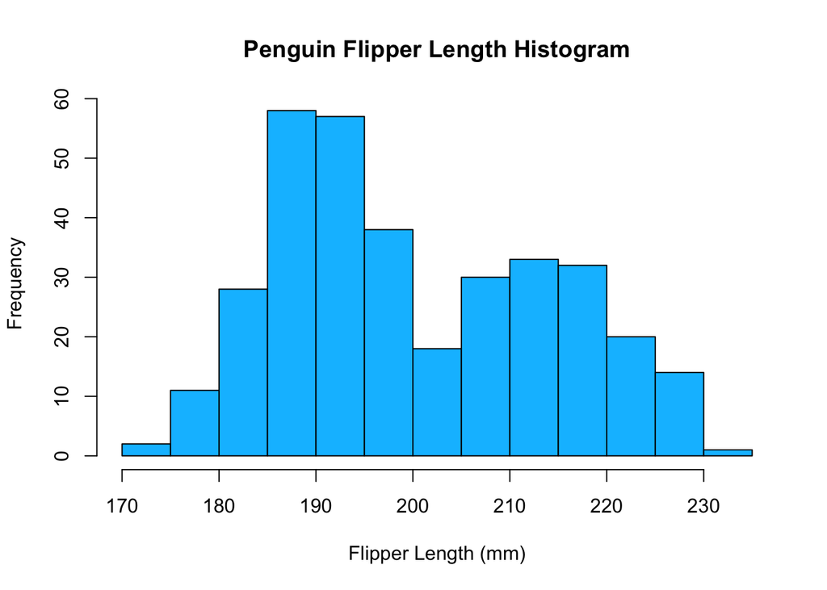

```r
hist(penguins$flipper_length_mm,
     breaks = 9,
     main = "Penguin Flipper Length Histogram",
     xlab = "Flipper Length (mm)",
     col = "deepskyblue1")
```

### boxplot() function

1. a simple boxplot of ginkgo petiole lengths

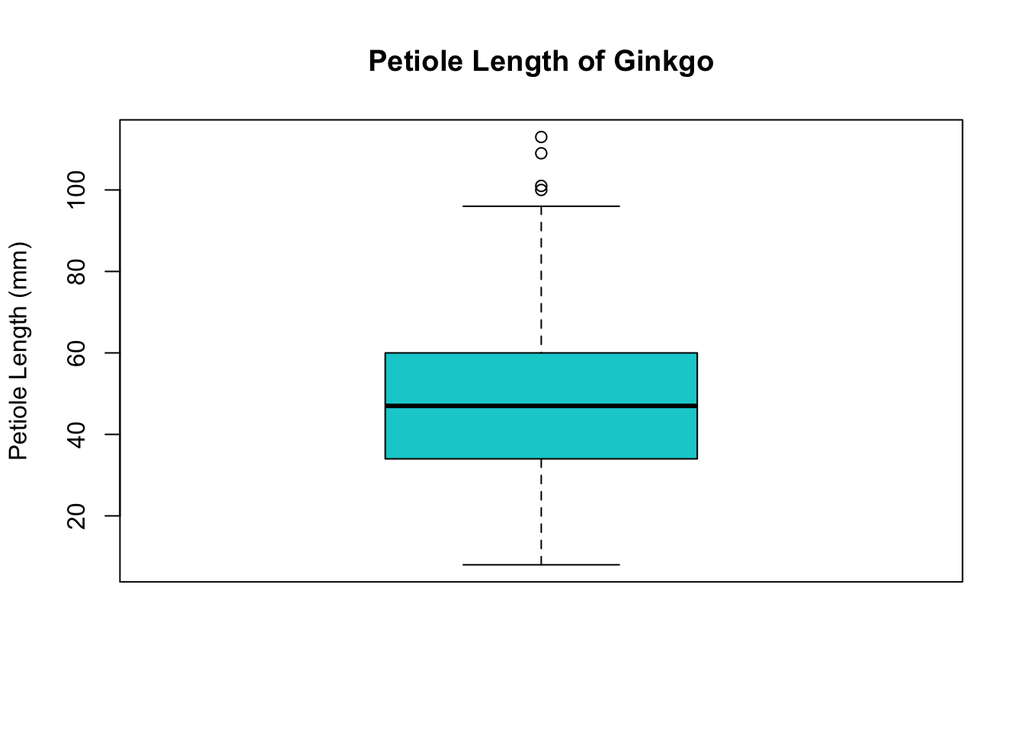

```r
boxplot(
  ginkgo$petiole_length,
  main = "Petiole Length of Ginkgo",
  ylab = "Petiole Length (mm)",
  col = "darkturquoise"
)
```

2. conditional boxplot of one of the continuous variables conditioned on the seeds_present column

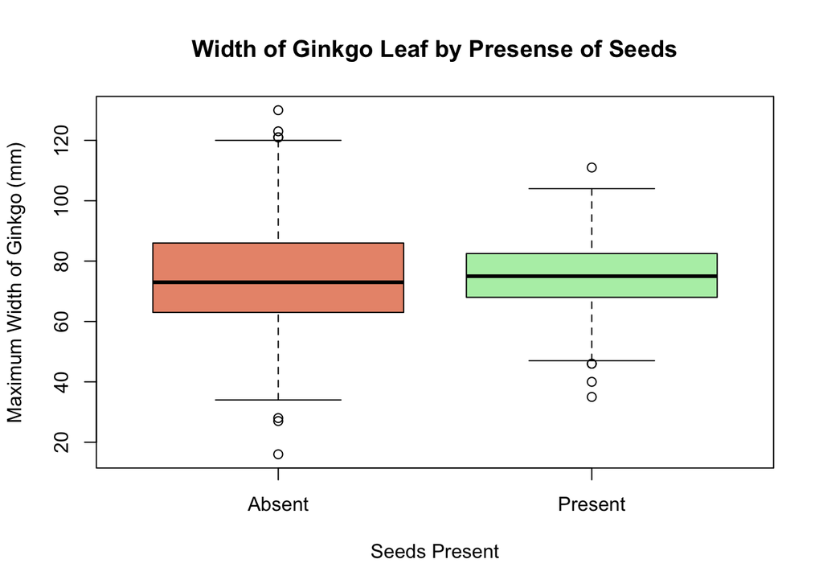

```r
boxplot(
  data = ginkgo, max_width ~ seeds_present,
  main = "Width of Ginkgo Leaf by Presense of Seeds",
  xlab = "Seeds Present",
  ylab = "Maximum Width of Ginkgo (mm)",
  names = c("Absent", "Present"),
  col = c("darksalmon", "darkseagreen2")
)
```